# Markov chain Monte Carlo sampling algorithms

Lecture 5

Dr Samuel Livingstone

# Last time

- Theory of MCMC
  - Bias (via mixing times)
    $$\|P^n(x,\cdot) - \pi\|_{TV} \leq M(x) \rho^n$$
  - (Asymptotic) Variance
    $$\nu(P,f) := \lim_{N \to \infty} N\text{Var}(\tilde{f}_N)$$

# Outline

- Gradient-based algorithms
  - Metropolis-adjusted Langevin algorithm (MALA)
  - Unadjusted algorithms & stochastic gradients
  - Hamiltonian Monte Carlo
- Other approaches
  - Parallel tempering
  - Adaptive MCMC
- *(Appendix: case studies)*
  - *(Bayesian variable selection in regression)*
  - *(Modelling radioactivity on Rongelap island via Generalised linear spatial models)*

# Part 1: Gradient-based algorithms

# Motivation for better Metropolis–Hastings

- Recall that in Metropolis–Hastings the key design choice is the candidate kernel/proposal distribution
  $$Q(x,\cdot)$$
- We have seen that simple random walk moves can be surprisingly effective
- You can (indeed you *should*) always run longer chains to ensure the ESS is sufficiently high etc.
- But no information about $\pi$ is used to design $Q(x,\cdot)$
- **Can we do better?**

# How does the Random Walk Metropolis perform in high dimension?

- Consider a simple choice of target $\pi^{(d)}(x)$ as $N(0,I_{d \times d})$, for $d \in \{10,20,30,40,50,60,70,80,90,100\}$
- We implement an optimally tuned Random Walk Metropolis in each case ($\alpha \approx 0.234$)
- Then we study the mixing time, meaning
  $$t^*(\epsilon) := \inf\{t \geq 0 : \|P^t(x,\cdot) - \pi\|_{TV} \leq
  \epsilon \}$$

# The mixing time is typically $O(d)$ *(good, but let’s try to do better)*

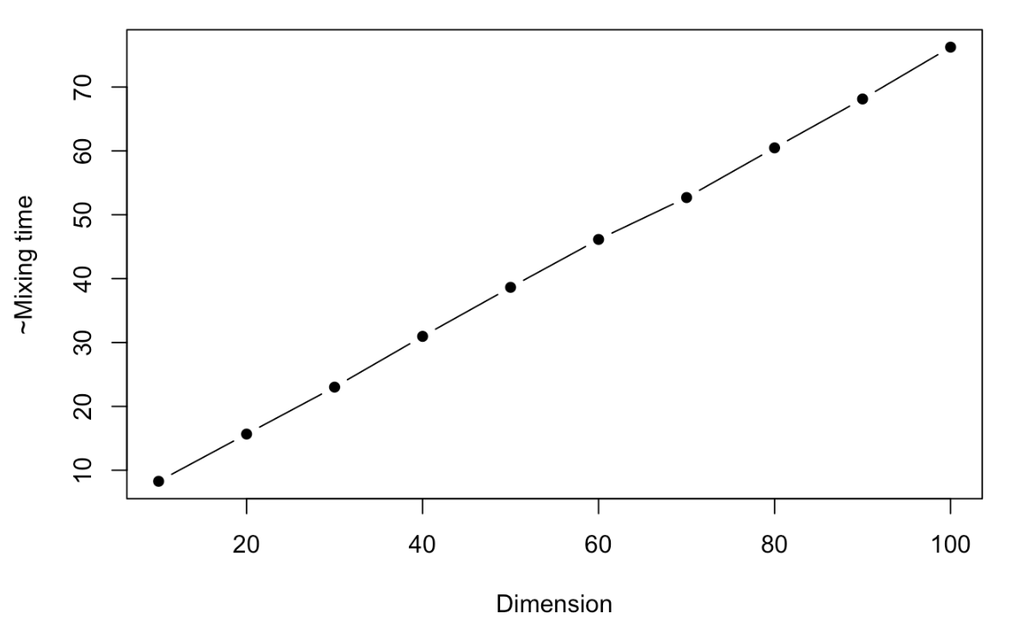

# A popular modern strategy for constructing Metropolis–Hastings algorithms

1. Find a $\pi$-invariant stochastic process $(Y_t)_{t\geq 0}$
   - *(usually continuous time, usually not possible to simulate exactly)*
2. Approximate the dynamics of the process
   - *(this is construction of $Q(x,\cdot)$)*
3. Correct for approximation errors with Metropolis–Hastings step
   - *(ensures $\pi$ is equilibrium distribution)*
- We will focus on $E = \mathbb{R}^d$, but strategy can be employed on any space if a $\pi$-invariant process can be found

# Diffusion processes

- One example of a continuous-time stochastic process that cannot usually be simulated is a *diffusion process*
- The dynamics are described via a stochastic differential equation (SDE)
  - **Question.** How many people have studied diffusions/SDEs?
- Consider diffusion process $(Y_t)_{t \geq 0}$, with corresponding SDE
  $$dY_t = b(Y_t)dt + \sigma(Y_t)dW_t, \qquad Y_0 = y_0$$
- This is just notation!
  - $b:\mathbb{R}^d \to \mathbb{R}^d$ *drift*, $\sigma:\mathbb{R}^d \to \mathbb{R}^{d \times d}$ *volatility*
- If $Y_t = y_t$ then for small $\delta > 0$
  $$\begin{aligned}
  \mathbb{E}[Y_{t+\delta}]
  &=
  y_t + b(y_t)\delta + o(\delta)
  \\
  \text{Cov}(Y_{t+\delta})
  &= \sigma(y_t)\sigma(y_t)^T\delta^2 + o(\delta^2)
  \end{aligned}$$
- The process $(W_t)_{t \geq 0}$ is called a **standard Wiener process**, or Brownian motion
  - $W_0 = 0$, and for any $t > s > 0$
    $$W_t - W_s \sim N(0,t-s I_{d \times d})$$

# Simulating diffusion processes

- Note that the true process satisfies
  $$Y_{t+h} = Y_t + \int_t^{t+h} b(Y_s)ds +
  {\int_t^{t+h}\sigma(Y_s)dW_s}_{\text{Stochastic `Ito' integral}}$$
- Assume that $b(Y_s) \approx b(Y_t)$ over the interval $s \in [t,t+h]$ (and similarly for $\sigma(Y_t)$), for small enough $h>0$
- This gives the approximation
  $$Y_{t+h}
  \approx
  Y_t + b(Y_t)\int_t^{t+h}ds + \sigma(Y_t)\int_t^{t+h} dW_s$$
- The integrals can now be evaluated, giving
  $$Y_t + b(Y_t)h + \sigma(Y_t)(W_{t+h} - W_t)$$
- Rearranging and writing $W_{t+h} - W_t := \sqrt{h}Z_{t+h}$, where $Z_{t+h} \sim N(0,I)$ gives **Euler–Maruyama numerical scheme**
  $$Y_{t+h} = Y_t + b(Y_t)h + \sqrt{h}\sigma(Y_t)Z_{t+h}$$

# A simulation of the diffusion with SDE $dY_t = dW_t$ for $t\in [0,1]$ (Euler–Maruyama skeleton + interpolation)

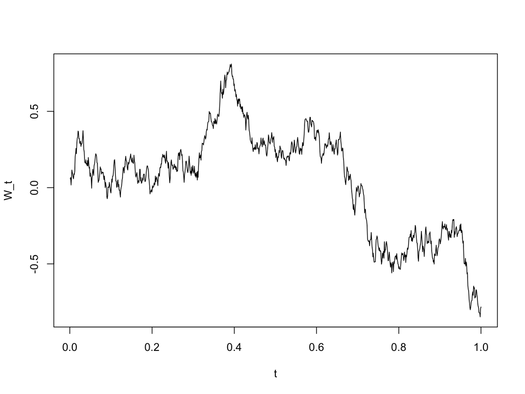

```r
set.seed(5367)
delta <- 1/1000        # time step
dW <- sqrt(delta)*rnorm(1000)
W <- cumsum(dW)
plot((1:1000)/1000,W, type = 'l', xlab = "t",ylab = "W_t")
```

# The (overdamped) Langevin diffusion

- Let $(Y_t)_{t\geq 0}$ be a diffusion process, and write $Y_t \sim \mu_t$
- Our goal is to construct a diffusion process for which as $t\to\infty$
  $$\|\mu_t - \pi\|_{TV} \to 0$$
- **Question.** What should we call $\pi$ if this is the case?
- The following diffusion has exactly this property under mild regularity conditions on $\pi$
  $$dY_t = \frac{1}{2}\nabla\log\pi(Y_t)dt + dW_t$$
- It is not hard to show that $\pi$ is invariant using the Fokker–Planck/Kolmogorov forward equation (I will not cover this)

# Using the Langevin diffusion to construct MCMC proposals

- The Euler–Maruyama numerical scheme can be used to generate Metropolis–Hastings proposals
- If current state $X_n = x$ we can choose our Metropolis–Hastings proposal as
  $$Y = x + \frac{h}{2}\nabla\log\pi(x) + \sqrt{h}Z$$
  where $Z \sim N(0,I)$
- This means that candidate kernel $Q(x,\cdot)$ takes the form
  $$Q(x,\cdot) = N\left(x+\frac{h}{2}\nabla\log\pi(x), hI\right)$$
- We then accept-reject the proposed move using the Metropolis–Hastings ratio
  $$\alpha(x,y) = \min\left(1, \frac{\pi(y)q(y,x)}{\pi(x)q(x,y)} \right)$$
- This is called the **Metropolis-adjusted Langevin algorithm (MALA)**
  - **Question.** Does $q(x,y) = q(y,x)$ here?